# zadanie6

Natalia Mańkowska

# Wpływ społeczny

Jest to proces, w wyniku którego dochodzi do zmiany **zachowania**, **opinii** lub **uczuć** człowieka wskutek tego, co **robią**, **myślą** lub **czują** inni ludzie.

### Wpływ społeczny charakteryzuje się tym, że:

1. nie musi być intencjonalny,
2. jest integralną częścią życia społecznego,
3. nie musi być uświadomiony przez osobę, na której się go wywiera.

### Trzy najczęstsze przypadki wpływu:

- **naśladownictwo**
  - efekt Wertera
  - ziewanie
  - teoria społecznego uczenia się (Bandura)
- **konformizm**
  - wpływ normatywny i informacyjny
  - konformizm zewnętrzny i wewnętrzny
  - badania Ascha
- **uleganie autorytetom**
  - czynniki zwiększające siłę autorytetu:
    - mundur
    - tytuł - prof., dr, ks., itp.
    - efekt *amerykańskich naukowców*
  - badania Milgrama

### Mechanizmy wywierania wpływu społecznego:

[output not shown]

[A oto filmik, w którym reguły wywierania wpływu są krótko omówione.](https://www.youtube.com/watch?v=3-T-dr9oB2w)

#### Poruszając temat wpływu społecznego, grzechem byłoby nie wspomnieć o guru w tej kwestii - Robercie Cialdinim i jego technikach manipulacji. Oto niektóre z nich:

- stopa w drzwiach
- niska piłka
- drzwiami w twarz

`Czy istnieje na świecie ktoś, kto nie pomyślał, że te nazwy są dziwne?`

[figure not shown]

**Oto najpopularniejsza książka R. Cialdiniego**

Inspired by: *prezentacja z psychologii społecznej*, 2017, Basiński K.

`A teraz nadszedł czas na spełnienie kolejnych wymaganych podpunktów, bo zaliczenie z TIPN to ważna sprawa.`

#### Oto wykres przedstawiający liczbę samochodów wybranych modeli produkowanych w latach 1999 - 2008:

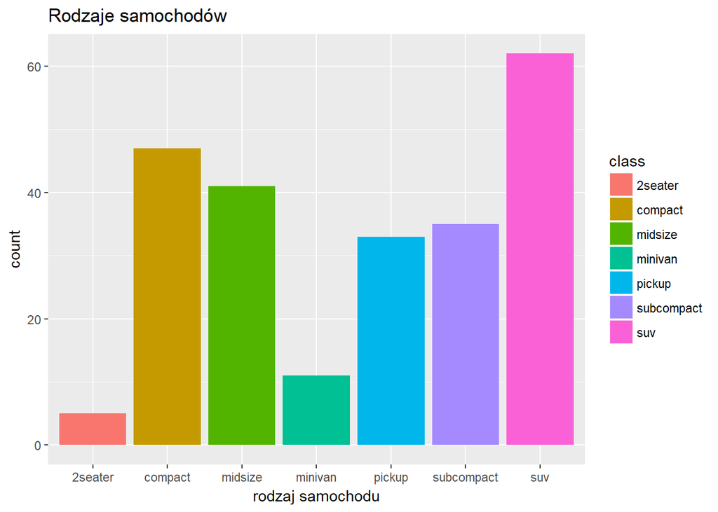

```r
library(tidyverse)

ggplot (data = mpg) +
  geom_bar(mapping = aes(x = class, fill = class)) +
  labs(title = "Rodzaje samochodów", x = "rodzaj samochodu")
```

#### W poniższej tabeli ukazane są ceny diamentów (w $), zależne m. in. od liczby karatów w tych kamieniach.

```r
library(tidyverse)
data(diamonds)
select(diamonds, carat, price)
```

| carat | price |
| --- | --- |
| 0.23 | 326 |
| 0.21 | 326 |
| 0.23 | 327 |
| 0.29 | 334 |
| 0.31 | 335 |
| 0.24 | 336 |
| 0.24 | 336 |
| 0.26 | 337 |
| 0.22 | 337 |
| 0.23 | 338 |

[output cut: 9990 more lines]

#### Oto tabela, która zawiera filmy (a dokładniej dramaty) powstałe po roku 1997 włącznie.

```r
library (tidyverse)
library(readr)
movies <- read_csv("movies.csv")

dramaty <- filter(movies, Drama == 1, year >= 1997)

arrange(dramaty, desc(length))
```

| title | year | length | budget | rating | votes | mpaa | Action | Animation | Comedy | Drama | Documentary | Romance | Short |
| --- | --- | --- | --- | --- | --- | --- | --- | --- | --- | --- | --- | --- | --- |
| Ebolusyon ng isang pamilyang pilipino | 2004 | 647 | NA | 8.4 | 5 | NA | 0 | 0 | 0 | 1 | 0 | 0 | 0 |
| Commune (Paris, 1871), La | 2000 | 555 | NA | 7.8 | 33 | NA | 0 | 0 | 0 | 1 | 0 | 0 | 0 |
| Batang West Side | 2002 | 300 | NA | 7.3 | 13 | NA | 0 | 0 | 0 | 1 | 0 | 0 | 0 |
| Kaaka Kaaka | 2003 | 300 | NA | 7.6 | 26 | NA | 1 | 0 | 0 | 1 | 0 | 1 | 0 |
| Bab el shams | 2004 | 278 | NA | 8.6 | 51 | NA | 0 | 0 | 0 | 1 | 0 | 1 | 0 |
| 10 jaar leuven kort | 2004 | 240 | NA | 7.9 | 7 | NA | 0 | 0 | 0 | 1 | 0 | 0 | 1 |
| Familien Gregersen | 2004 | 240 | NA | 5.1 | 46 | NA | 0 | 0 | 0 | 1 | 0 | 0 | 0 |
| Lagaan: Once Upon a Time in India | 2001 | 224 | NA | 7.5 | 2717 | PG | 0 | 0 | 0 | 1 | 0 | 1 | 0 |
| Eureka | 2000 | 217 | NA | 7.6 | 558 | NA | 0 | 0 | 0 | 1 | 0 | 0 | 0 |
| Kabhi Khushi Kabhie Gham... | 2001 | 210 | NA | 7.3 | 808 | NA | 0 | 0 | 0 | 1 | 0 | 1 | 0 |

[output cut: 3525 more lines]

### Dziękuję za uwagę, swoją przygodę z R Markdown uważam za (chyba) niezakończoną - może kiedyś zacznę robić tu notatki, bo serio wyglądają ładnie.